# Lathyrus ms2: selection on reaction norms for flowering time

# Univariate models

## FFD with random effect of year only

```r
my.cores <- detectCores()
```

```r
univar.FFD_yearonly.all.brm<-brm(formula=FFD~cmean_4+(1|year),data=datadef,
                warmup = 1000,iter = 4000,thin=2,chains=4,
                # 4 chains, each with 4000 iterations
                inits = "random",seed = 12345,cores = my.cores)
# Total of 6000 post-warmup samples
```

```r
summary(univar.FFD_yearonly.all.brm)
```

[output not shown]

## FFD with random effects of year and individual-intercept

```r
univar.FFD.all.brm<-brm(formula=FFD~cmean_4+(1|year)+(1|id),data=datadef,
                warmup = 1000,iter = 4000,thin=2,chains=4,
                # 4 chains, each with 4000 iterations
                inits = "random",seed = 12345,cores = my.cores)
# Total of 6000 post-warmup samples
```

```r
summary(univar.FFD.all.brm)
```

[output not shown]

## Random regression for FFD, including random effects of individual slopes and covariance between intercept and slope

```r
univar.FFD_RR.all.brm<-brm(formula=FFD~cmean_4+(1|year)+(cmean_4|id),
                           data=datadef,
                           warmup = 1000,iter = 4000,thin=2,chains=4,
                           inits = "random",seed = 12345,cores = my.cores,
                           sample_prior="yes")
# Total of 6000 post-warmup samples
```

```r
summary(univar.FFD_RR.all.brm)
```

[output not shown]

### Graph model prediction for each id

```r
predict_id<-ggpredict(univar.FFD_RR.all.brm,
                          terms=c("cmean_4","id"),type="random")
```

```
Note: uncertainty of error terms are not taken into account. You may want to use `rstantools::posterior_predict()`.
```

```r
predict_mean<-ggpredict(univar.FFD_RR.all.brm,terms=c("cmean_4"),type="random")
```

```
Note: uncertainty of error terms are not taken into account. You may want to use `rstantools::posterior_predict()`.
```

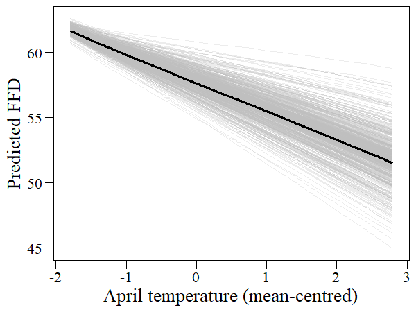

```r
ggplot()+
  geom_line(data=data.frame(predict_id),aes(x=x,y=predicted,group=group),
            color="grey",size=0.01,alpha=0.3)+
  geom_line(data=data.frame(predict_mean),aes(x=x,y=predicted),
            color="black",size=1)+
  my_theme()+
  xlab("April temperature (mean-centred)")+
  ylab("Predicted FFD")
```

## Compare models

This allows us to test if adding among-individual variation in elevation and slope of the RN improves model fit.

```r
loo_comp<-loo_compare(univar.FFD_yearonly.all.brm,univar.FFD.all.brm,
                      univar.FFD_RR.all.brm, criterion="loo")
```

```r
loo_comp
```

```
                            elpd_diff se_diff
univar.FFD_RR.all.brm         0.0       0.0
univar.FFD.all.brm          -13.2       8.1
univar.FFD_yearonly.all.brm -58.9      13.4
```

The results indicate that adding a random intercept (i.e. among-individual variation in RN elevation) improves the fit, and that adding a random slope (i.e. among-individual variation in RN slope) improves the fit even more. Thus, the random regression model is the best model.

## Model evaluation for random regression model

I used some code from https://biol609.github.io/lectures/23c_brms_prediction.html#24_evaluating_brms_models

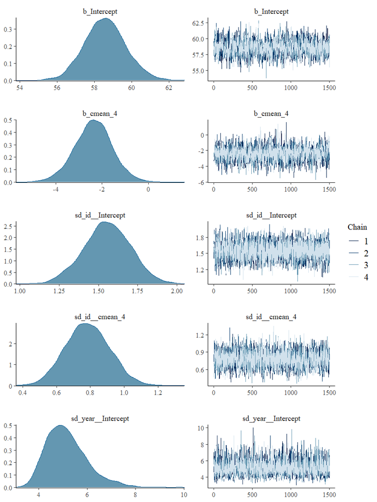

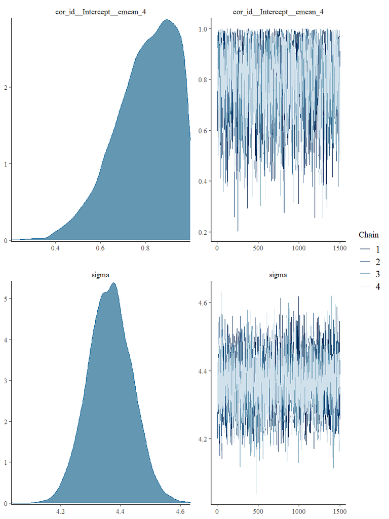

```r
plot(univar.FFD_RR.all.brm)
```

Rhat (potential scale reduction statistic): monitors whether a chain has converged to the equilibrium distribution by comparing its behavior to other randomly initialized chains.

- light: below 1.05 (good)
- mid: between 1.05 and 1.1 (ok)
- dark: above 1.1 (too high)

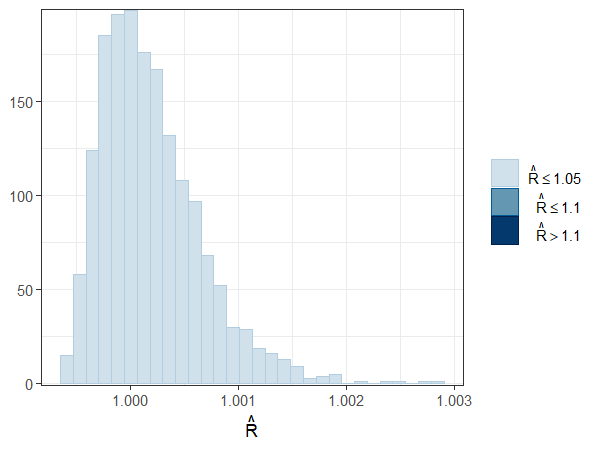

```r
mcmc_rhat_hist(rhat(univar.FFD_RR.all.brm))+theme_bw()
```

Effective sample size: an estimate of the number of independent draws from the posterior distribution of the estimand of interest.

- light: between 0.5 and 1 (high)
- mid: between 0.1 and 0.5 (good)
- dark: below 0.1 (low)

We should worry about any values less than 0.1.

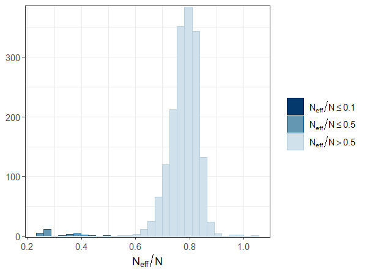

```r
mcmc_neff_hist(neff_ratio(univar.FFD_RR.all.brm))+theme_bw()
```

Everything seems OK till here.

Autocorrelation: Takes very long / gets stuck, see later.

```r
# mcmc_acf(univar.FFD_RR.all.brm,lags=20)
```

Assessing fit:

Posterior predictive checks: Compares observed data to simulated data from the posterior predictive distribution (if a model is a good fit, we should be able to use it to generate data that resemble the data that we observed).

I used some code from https://cran.r-project.org/web/packages/bayesplot/vignettes/graphical-ppcs.html#:~:text=MCMC%20diagnostics%20vignette.-,Graphical%20posterior%20predictive%20checks%20(PPCs),Gabry%20et%20al%2C%202019).

```r
y1<-subset(datadef,!is.na(FFD))$FFD # vector of outcome values
yrep3<-posterior_predict(univar.FFD_RR.all.brm, draws = 500)
# matrix of draws from the posterior predictive distribution
```

Each row of the matrix is a draw from the posterior predictive distribution, i.e. a vector with one element for each of the data points in y.

Comparison of the distribution of y and the distribution of the simulated dataset in the yrep matrix

```r
ppc_dens_overlay(y1, yrep3[1:500,])
```

[output not shown]

Does this look good enough?

Separate histograms of y and some of the yrep datasets

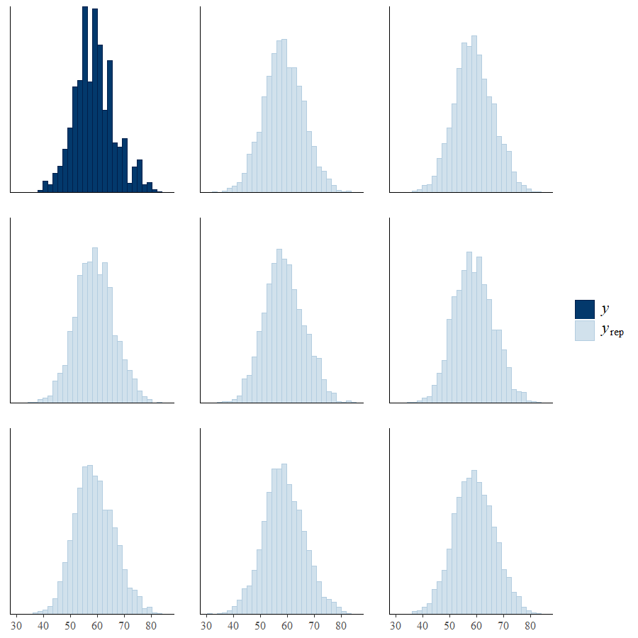

```r
ppc_hist(y1, yrep3[1:8, ])
```

Does this look good enough?

```r
ppc_stat(y1,yrep3,stat="median")
```

[output not shown]

Measure of fit: Bayesian R2, which looks at the model expected variance / (expected variance + residual variance).

```r
bayes_R2(univar.FFD_RR.all.brm)
```

[output not shown]

Leave-one-out cross validation (LOO):

I used code from https://www.monicaalexander.com/posts/2020-28-02-bayes_viz/

We are interested in estimating the out-of-sample predictive accuracy at each point i, when all we have to fit the model is data that without point i. We want to estimate the leave-one-out (LOO) posterior predictive densities and a summary of these across all points, which is called the LOO expected log pointwise predictive density. The bigger the numbers, the better we are at predicting the left out point i.

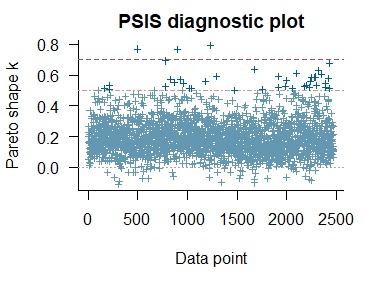

```r
plot(loo1)
```

We have 3 obs with k > 0.7 - how bad is this?

Is this OK?

## Extract BLUPs from random regression model

Code was checked by Piet.

```r
BLUPs_MCMC.all.brms  <- cbind(as.factor(c(1:837)),
                              as.data.frame(ranef(univar.FFD_RR.all.brm)$id)
                              [c(1:2,5:6)])
colnames(BLUPs_MCMC.all.brms) <- c("id", "intercept", "intercept_sd",
                                   "slope","slope_sd")
with(BLUPs_MCMC.all.brms,cor(intercept,slope)) # highly correlated!
```

```
[1] 0.9623359
```

Plots with BLUPs

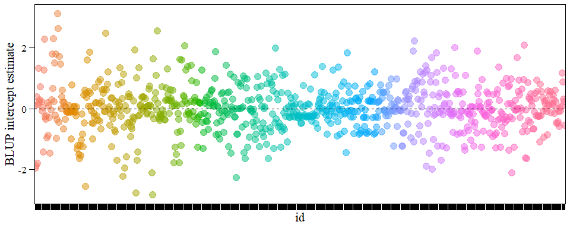

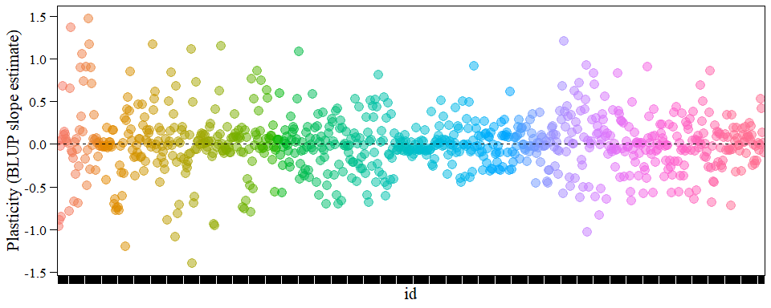

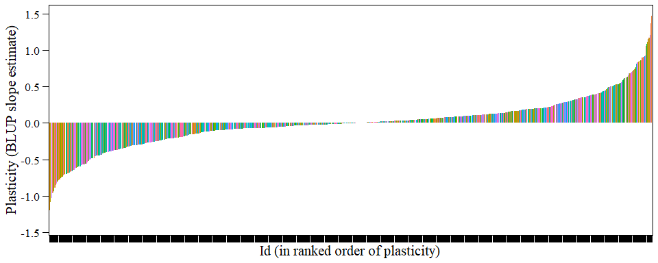

Add BLUPs to data set

```r
datadef<-datadef%>%left_join(BLUPs_MCMC.all.brms%>%
                               dplyr::select(intercept,intercept_sd,
                                             slope,slope_sd)%>%
                               rownames_to_column(var="id"))
```

## Figure 1

```r
predict_id_2<-ggpredict(univar.FFD_RR.all.brm,
                      terms=c("cmean_4","id"),type="random")
```

```
Note: uncertainty of error terms are not taken into account. You may want to use `rstantools::posterior_predict()`.
```

```r
predict_mean_2<-ggpredict(univar.FFD_RR.all.brm,terms=c("cmean_4"),
                          type="random")
```

```
Note: uncertainty of error terms are not taken into account. You may want to use `rstantools::posterior_predict()`.
```

```
Warning: Removed 4359 rows containing missing values (geom_point).
```

[figure not shown]

```r
plot_grid(ggplot()+
            geom_line(data=data.frame(predict_id_2),
                      aes(x=x,y=predicted,group=group),
                      color="#FF9999",size=0.01,alpha=0.5)+
            geom_line(data=data.frame(predict_mean_2),aes(x=x,y=predicted),
                      color="red",size=1)+
            geom_jitter(data=datadef,aes(x=cmean_4,y=FFD),size=2,alpha=0.05,
                        width=0.05,height=0.1)+
            my_theme()+
            xlab("April temperature (mean-centered)")+
            ylab("Predicted FFD"),
          plot_grid(ggplot(BLUPs_MCMC.all.brms,
                           aes(x=intercept+fixef(univar.FFD_RR.all.brm)[1]))+
                      geom_histogram(fill="#FF9999",color="black")+my_theme()+
                      geom_vline(xintercept=fixef(univar.FFD_RR.all.brm)[1],
                                 size=0.5,linetype="dashed")+
                      ylab("Number of\nindividuals"),
                    ggplot(BLUPs_MCMC.all.brms,
                           aes(x=slope+fixef(univar.FFD_RR.all.brm)[2]))+
                      geom_histogram(fill="#FF9999",color="black")+my_theme()+
                      geom_vline(xintercept=fixef(univar.FFD_RR.all.brm)[2],
                                 size=0.5,linetype="dashed")+
                      xlab("Slope of the reaction norm")+
                      ylab("Number of\nindividuals"),
                    ncol=1,labels=c("B)","C)"),label_fontfamily="serif"),
          labels = c("A)",""),label_fontfamily="serif",rel_widths = c(2,1.5))
```

```r
ggsave(filename="output/figures/fig1.tiff",
       device="tiff",width=22,height=12,units="cm",dpi=300,compression="lzw")
```

# Bivariate models

## 1. mean_fitness_fl, no condition variable

Using the ID-syntax to specify fitness to be correlated with the intercept and slope of FFD on temperature - code has been checked by Piet.

Regarding distributions, I tried Poisson distribution for fitness, but not sure how eventual overdispersion is handled. I also tried using a negative binomial distribution. Results seem quite similar.Maybe we should consider trying a zero-inflated negative binomial (I did some attempts but seems to take much longer!).

### Poisson distribution

```r
datadef<-left_join(datadef,datadef_total[c(1:3,9)])
# Add info on mean fitness and mean shoot volume
bf_FFD <- bf(FFD ~ cmean_4 + (cmean_4|ID1|id) + (1|year)) # Set up model formula
bf_fitness <- bf(round(mean_fitness_fl) ~  (1|ID1|id)) # Set up model formula
# Specifying group-level effects of the same grouping factor (id here)
```

Save data with BLUPs

```r
write_csv(datadef,file = "data/datadef_BLUPs.csv")
```

```r
bivar1.all.brm.pois<-brm(bf_FFD + bf_fitness, family = c(gaussian, poisson),
                         data = datadef,
                         warmup = 1000,iter = 4000,chains=4,thin=2,
                         inits = "random",seed = 12345,cores = my.cores,
                         save_all_pars=TRUE)
# Total of 6000 post-warmup samples
```

```r
summary(bivar1.all.brm.pois)
```

[output not shown]

### Negative binomial distribution

```r
bivar1.all.brm.nb<-brm(bf_FFD + bf_fitness, family = c(gaussian, negbinomial),
                       data = datadef,warmup = 1000,iter = 4000,chains=4,thin=2,
                         inits = "random",seed = 12345,cores = my.cores,
                       save_all_pars=TRUE)
```

```r
print(bivar1.all.brm.nb,digits=3)
```

[output not shown]

### Negative binomial distribution with zero-inflation

```r
bivar1.all.brm.zinb<-brm(bf_FFD + bf_fitness,
                         family = c(gaussian, zero_inflated_negbinomial),
                       data = datadef,warmup = 1000,iter = 4000,chains=4,thin=2,
                         inits = "random",seed = 12345,cores = my.cores)
```

```r
summary(bivar1.all.brm.zinb)
```

[output not shown]

### Model evaluation: Compare models

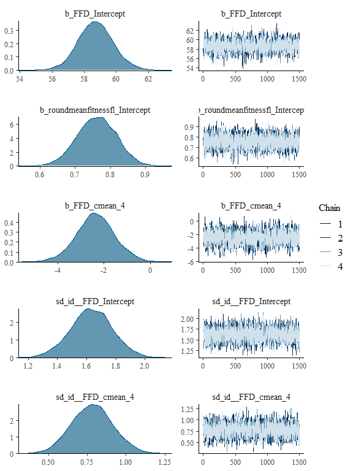

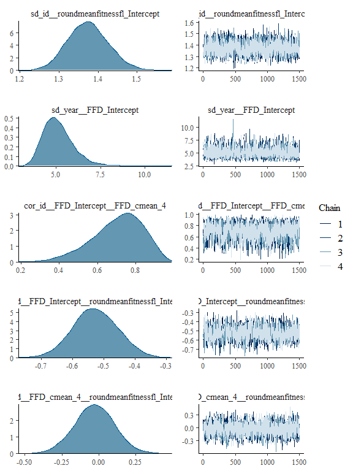

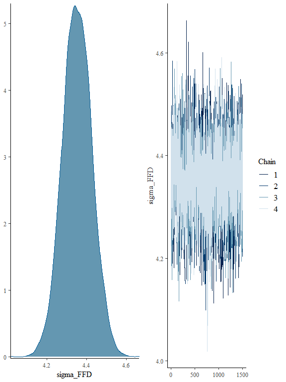

```r
plot(bivar1.all.brm.pois)
```

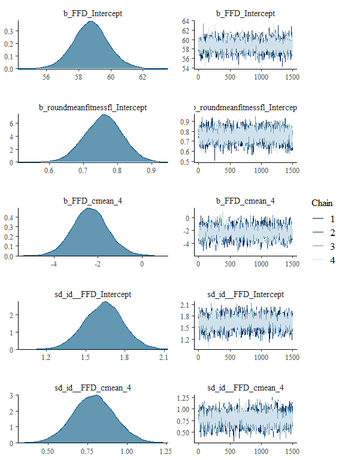

```r
plot(bivar1.all.brm.nb)
```

[figure not shown]

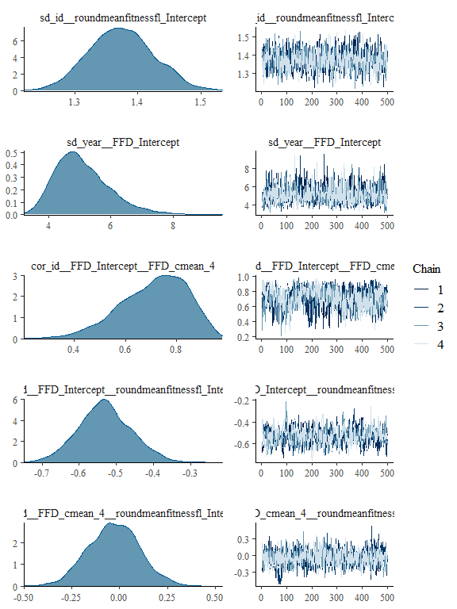

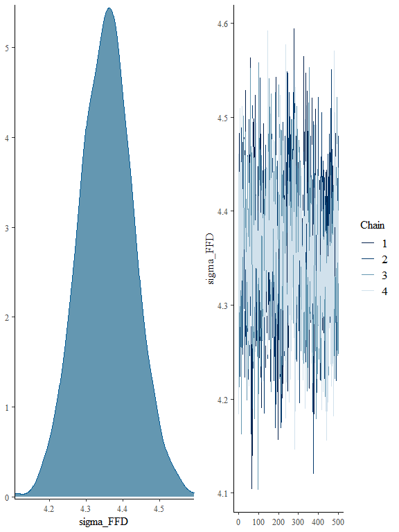

```r
plot(bivar1.all.brm.zinb)
```

Rhat

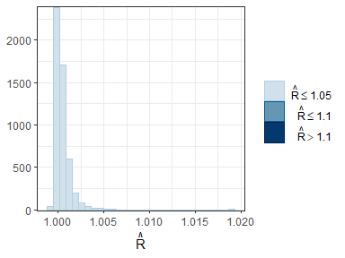

```r
mcmc_rhat_hist(rhat(bivar1.all.brm.pois))+theme_bw()
```

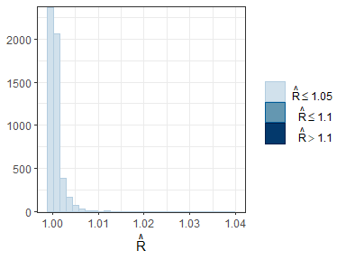

```r
mcmc_rhat_hist(rhat(bivar1.all.brm.nb))+theme_bw()
```

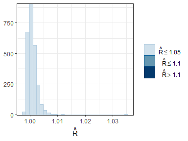

```r
mcmc_rhat_hist(rhat(bivar1.all.brm.zinb))+theme_bw()
```

Effective sample size:

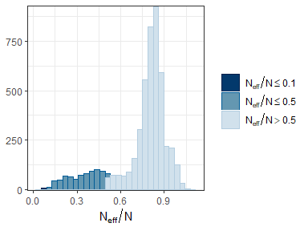

```r
mcmc_neff_hist(neff_ratio(bivar1.all.brm.pois))+theme_bw()
```